# Malaria Importation

David Smith

11/22/2021

RAMP / Human Mobility | Time Spent | Malaria Importation

## MIS Data

- We know the fraction that have traveled
- We know parasite positivity, given travel

## Time Spent

Let $\tau$ denote the rate people take trips, with an average duration of $\phi$ days. Let $X$ denote the proportion of the population at home. We get

$$\frac{dX}{dt} = -\tau X + \phi
(1-X).$$

The fraction of of the population at home is:

$$\hat X = \frac{\phi}
{\phi+\tau}$$
For example, if people take trips that last approximately a week once every 6 months, then the fraction of time not traveling is approximately $96.3\%$.

```r
phi = 1/7
tau = 1/180
phi / (phi+tau)
```

```
## [1] 0.9625668
```

## Recently Traveled

What fraction has recently traveled? We let $1/\alpha$ define recent travel, and we develop a new variable $Y$ and we assume that another trip could happen in the meantime, so:

$$\frac{dY}{dt} = \phi (1-X) - \alpha
Y$$

Now, we get:

$$\hat Y = \frac{\phi \tau}{\alpha
(\phi+\tau)}$$
With the same numbers above, the fraction that has traveled within the past 8 weeks is approximately $22.8\%$:

```r
phi = 1/7
tau = 1/180
alpha = 1/56
phi*tau/(alpha+tau)/(phi+tau)
```

```
## [1] 0.2284057
```

## PR

We want to estimate the travel fraction under the model:
$$\frac{dm}{dt} = h + \delta - rm$$

Let $h$ denote the FoI in and around home, and let $\breve h$ denote the FoI while traveling. The total FoI for the population is:
$$\frac{dm}{dt} = h \frac{\phi}{\phi+\tau} +
\breve h \frac{\tau}{\phi +\tau} - rm$$
so that the total FoI is
$$\bar m = \frac{h}{r}
\frac{\phi}{\phi+\tau} + \frac{\breve h}{r} \frac{\tau}{\phi
+\tau}$$
and the PR is
$$1-e^{-\bar
m}.$$

**Note** In RM-spatial, $\delta = \breve h \frac{\tau}{\phi + \tau}$, and the row-sums of the travel matrix $\Theta$ should add up to $\frac{\phi}{\phi+\tau}$.

## Travel Fraction

At the baseline, we assume a person leaving for a trip has MoI $m$. While they are away, the MoI in travelers $m'$ changes at a different rate:
$$\frac{d\breve m}{dt} =
\breve h - r \breve m$$

with the initial condition
$$\breve m(0) =
\bar m$$

While traveling, the MoI increases:

$$\breve m(t) = \frac{\breve h}{r}
- e^{-rt} \left(\frac{\breve h}{r} - \frac{h}{r} \right)$$

After a trip of length $1/\alpha$, the MoI would be:

$$\breve m(\alpha) = \frac{\breve h}{r}
- e^{-r/\alpha} \left(\frac{\breve h}{r} - \frac{h}{r} \right)$$
and $t$ days after returning home, the MoI would be:
$$\frac{h}{r} - e^{-rt} \left(\frac{h}{r} - \breve
m(\alpha) \right)$$
Averaging over $T$ days, we get that the moi in recently returned travelers is:

$$\tilde m = \frac{hT}{r} - \int_0^T
e^{-rt} \left(\frac{h}{r} - \breve m(\alpha) \right) dt$$
and the PR in recently returned travelers is
$$1
- e^{-\tilde m}$$

```r
fMoI = function(T=56, foi1=.1/365, foi2=20/365, r=1/50, phi=1/7, tau=1/180){
  tt  = 0:T
  alpha = 1/T
  moi0 = foi1/r
  moi1 = foi1/r*phi / (phi+tau) + foi2/r*tau/(phi+tau)
  pr1 = 1 - exp(-moi1)
  moi2 = foi2/r
  pr2 = 1 - exp(-moi2)

  moiT = moi2 - exp(-r*tt)*(moi2-moi1)
  moiR0 = moi2 - exp(-r/phi)*(moi2-moi1)
  moiR = moi1 - exp(-r*tt)*(moi1-moiR0)
  list(tt=tt, moi0=moi0, moi1 = moi1, moi2=moi2, moiR = moiR, moiT = moiT, mnR = mean(moiR), phi=phi, alpha=alpha, T=T)
}
```

```r
plot.trpr = function(fm){with(fm,{
  ix = round(1/phi)
   plot(tt, moiT, type = "l", ylim = range(0, moiT), col = "darkred", xlab = "Time (days)", ylab = "MoI")
   text(1/phi, 1.5*moiT[ix], expression(1/phi), pos = 3)
   lines(1/phi+tt, moiR, col = "darkblue")
   segments(1/phi, mnR, 1/phi+ T, mnR, lty=2)
   segments(1/phi, 1.5*moiT[ix], 1/phi,0)
   text(1/phi, 1.5*moiT[ix], expression(1/phi), pos = 3)
   segments(0, moi1, 1/phi+ T, moi1, col = grey(0.5))
})}
```

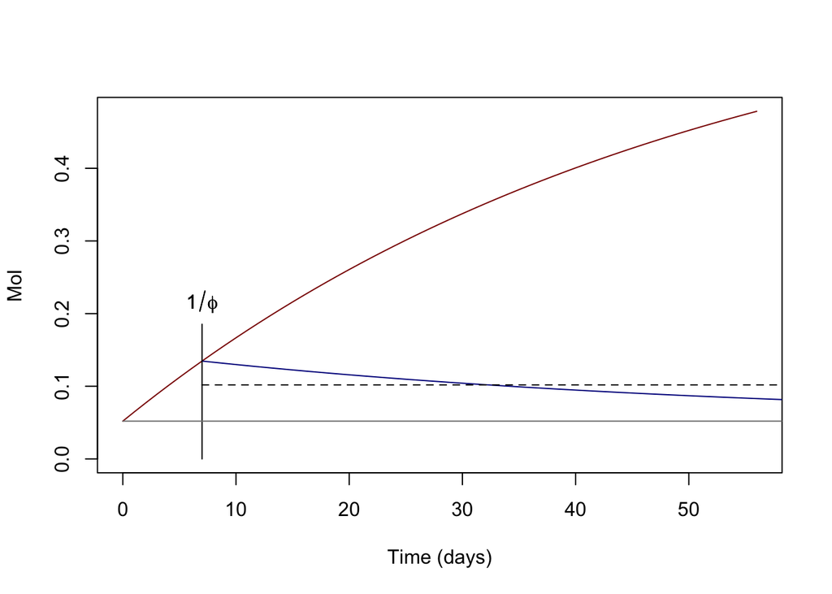

```r
fm = fMoI(foi1 = .2/365, foi2 = 5/365, r=1/50)
plot.trpr(fm)
```

## Estimate

**Pseudocode**

```r
tau2trpr = function(tau, alpha=1/56, phi=1/7){
  phi*tau/alpha/(phi+tau)
}

estimateTau = function(trpr, alpha, phi){
  ff = function(tau){
     (trpr - tau2trpr(tau, alpha, phi))^2
     abs(trpr - tau2trpr(tau, alpha, phi))^(1/2)
  }
  optimize(ff, c(0,1))$minimum
}
```

```r
estimateTau(.25, 1/56, 1/7) -> tau
tau
```

```
## [1] 0.0046135
```

```r
trpr = tau2trpr(tau)
trpr
```

```
## [1] 0.2502735
```

```r
estimateFoI = function(pfpr, r=1/100){
  ff = function(foi){
     moi = foi/r
     pr = 1-exp(-moi)
     abs(pfpr-pr)^(1/2)
  }
  optimize(ff, c(0,12)/365)$minimum
}
```

```r
estimateFoI(.25, 1/100)*365
```

```
## [1] 1.059016
```

```r
FoI2PR = function(foi1, foi2, TT=56,  r=1/100, phi=1/7, tau=1/180){
  alpha = 1/TT
  if (is.na(foi1)) browser()
  moi1 = foi1/r*phi/(phi+tau) + foi2/r*tau/(phi+tau)
  pr1 = 1-exp(-moi1)

  moi2 = foi2/r
  moiOnReturn = moi1 - exp(-r/phi)*(moi1-moi2)
  tt  = 0:TT
  pr2 = mean(moiOnReturn - exp(-r*tt)*(moiOnReturn-moi1))

  c(pr1=pr1, pr2=pr2)
}

d2FoI = function(x, pfpr1, pfpr2, TT=56,  r=1/100, phi=1/7, tau=1/180){
  prVals = FoI2PR(abs(x[1]), abs(x[2]), TT, r, phi, tau)
  sum((prVals-c(pfpr1, pfpr2))^2)
}
```

```r
FoI2PR(0.25/365, 2/365)
```

```
##        pr1        pr2
## 0.08280993 0.18710864
```

```r
FoI2PR(.2/365, 2/365) -> prs
d2FoI (c(1/365, 2/365), prs[1], prs[2])
```

```
## [1] 0.05845714
```

```r
travelFraction = function(trpr, pfpr1, pfpr2, TT=56, r=1/100, phi=1/7){

  alpha = 1/TT
  tau=estimateTau(trpr, alpha, phi)
  foi1a = estimateFoI(pfpr1, r)
  foi2a = estimateFoI(pfpr2, r)

  init = c(foi1a, foi2a)
  foi12 = abs(nlm(d2FoI, init, pfpr1=pfpr1, pfpr2=pfpr2, TT=TT, r=r, phi=phi, tau=tau)$estimate)
  h = foi12[1]
  foi2 = foi12[2]
  delta = foi2*tau/(phi+tau)
  TravFrac = delta/(h+delta)
  list(tau=tau, h=h, foi.away=foi2, delta=delta, TravFrac=TravFrac, aTrips = 365*tau, aFoI = h*365, aFoI2 = foi2*365, aDelta = 365*delta,  foi1a=foi1a, foi2a=foi2a) }
```

```r
trpr=0.22; pr1=.03; pr2=0.15
rr=1/200
travelFraction(trpr, pr1, pr2, r=rr)->out
#out

tau = out[[1]]
foi1 = out[[2]]
foi2 = out[[3]]

FoI2PR(foi1, foi2,  tau=tau, r=rr)
```

```
##        pr1        pr2
## 0.03022149 0.14994454
```

```r
FoI2PR(0.25/365, 2/365, tau = 1/180, r=1/200)
```

```
##       pr1       pr2
## 0.1587624 0.2866931
```

```r
tau2trpr(1/180)
```

```
## [1] 0.2994652
```

```r
travelFraction(0.299, 0.0828, .187, r=1/200)
```

```
## $tau
## [1] 0.005555651
##
## $h
## [1] 0.0002721208
##
## $foi.away
## [1] 0.004518839
##
## $delta
## [1] 0.0001691572
##
## $TravFrac
## [1] 0.3833347
##
## $aTrips
## [1] 2.027813
##
## $aFoI
## [1] 0.09932411
##
## $aFoI2
## [1] 1.649376
##
## $aDelta
## [1] 0.06174237
##
## $foi1a
## [1] 0.0004325135
##
## $foi2a
## [1] 0.001037664
```